# Happy Customer

### Conclusion

**Comparing all models**

```python
# training performance comparison

models_train_comp_df = pd.concat(
    [
        dtree_estimator_model_train_perf.T,
        dtree_estimator_model_train_perf.T,
        bagging_classifier_model_train_perf.T,
        bagging_estimator_tuned_model_train_perf.T,
        rf_estimator_model_train_perf.T,
        rf_tuned_model_train_perf.T,
        ab_classifier_model_train_perf.T,
        abc_tuned_model_train_perf.T,
        gb_classifier_model_train_perf.T,
        gbc_tuned_model_train_perf.T,
        xgb_classifier_model_train_perf.T,
        xgb_tuned_model_train_perf.T,
        stacking_classifier_model_train_perf.T,
    ],
    axis=1,
)
models_train_comp_df.columns = [
    "Decision Tree",
    "Tuned Decision Tree",
    "Bagging Classifier",
    "Tuned Bagging Classifier",
    "Random Forest",
    "Tuned Random Forest",
    "Adaboost Classifier",
    "Tuned Adaboost Classifier",
    "Gradient Boost Classifier",
    "Tuned Gradient Boost Classifier",
    "XGBoost Classifier",
    "XGBoost Classifier Tuned",
    "Stacking Classifier",
]
print("Training performance comparison:")
models_train_comp_df
```

```
Training performance comparison:
```

|  | Decision Tree | Tuned Decision Tree | Bagging Classifier | Tuned Bagging Classifier | Random Forest | Tuned Random Forest | Adaboost Classifier | Tuned Adaboost Classifier | Gradient Boost Classifier | Tuned Gradient Boost Classifier | XGBoost Classifier | XGBoost Classifier Tuned | Stacking Classifier |
| --- | --- | --- | --- | --- | --- | --- | --- | --- | --- | --- | --- | --- | --- |
| Accuracy | 0.651515 | 0.651515 | 0.924242 | 0.954545 | 0.954545 | 0.757576 | 0.727273 | 0.696970 | 0.954545 | 0.954545 | 0.954545 | 0.621212 | 0.484848 |
| Recall | 0.647059 | 0.647059 | 0.882353 | 0.970588 | 0.970588 | 0.705882 | 0.735294 | 0.676471 | 0.970588 | 0.970588 | 0.941176 | 1.000000 | 0.941176 |
| Precision | 0.666667 | 0.666667 | 0.967742 | 0.942857 | 0.942857 | 0.800000 | 0.735294 | 0.718750 | 0.942857 | 0.942857 | 0.969697 | 0.576271 | 0.500000 |
| F1 | 0.656716 | 0.656716 | 0.923077 | 0.956522 | 0.956522 | 0.750000 | 0.735294 | 0.696970 | 0.956522 | 0.956522 | 0.955224 | 0.731183 | 0.653061 |

```python
# testing performance comparison

models_test_comp_df = pd.concat(
    [
        dtree_estimator_model_test_perf.T,
        dtree_estimator_model_test_perf.T,
        bagging_classifier_model_test_perf.T,
        bagging_estimator_tuned_model_test_perf.T,
        rf_estimator_model_test_perf.T,
        rf_tuned_model_test_perf.T,
        ab_classifier_model_test_perf.T,
        abc_tuned_model_test_perf.T,
        gb_classifier_model_test_perf.T,
        gbc_tuned_model_test_perf.T,
        xgb_classifier_model_test_perf.T,
        xgb_tuned_model_test_perf.T,
        stacking_classifier_model_test_perf.T,
    ],
    axis=1,
)
models_test_comp_df.columns = [
    "Decision Tree",
    "Tuned Decision Tree",
    "Bagging Classifier",
    "Tuned Bagging Classifier",
    "Random Forest",
    "Tuned Random Forest",
    "Adaboost Classifier",
    "Tuned Adaboost Classifier",
    "Gradient Boost Classifier",
    "Tuned Gradient Boost Classifier",
    "XGBoost Classifier",
    "XGBoost Classifier Tuned",
    "Stacking Classifier",
]
print("Testing performance comparison:")
models_test_comp_df
```

```
Testing performance comparison:
```

|  | Decision Tree | Tuned Decision Tree | Bagging Classifier | Tuned Bagging Classifier | Random Forest | Tuned Random Forest | Adaboost Classifier | Tuned Adaboost Classifier | Gradient Boost Classifier | Tuned Gradient Boost Classifier | XGBoost Classifier | XGBoost Classifier Tuned | Stacking Classifier |
| --- | --- | --- | --- | --- | --- | --- | --- | --- | --- | --- | --- | --- | --- |
| Accuracy | 0.727273 | 0.727273 | 0.590909 | 0.636364 | 0.545455 | 0.545455 | 0.590909 | 0.727273 | 0.590909 | 0.454545 | 0.500000 | 0.681818 | 0.500000 |
| Recall | 0.636364 | 0.636364 | 0.272727 | 0.454545 | 0.363636 | 0.181818 | 0.363636 | 0.636364 | 0.272727 | 0.181818 | 0.272727 | 1.000000 | 1.000000 |
| Precision | 0.777778 | 0.777778 | 0.750000 | 0.714286 | 0.571429 | 0.666667 | 0.666667 | 0.777778 | 0.750000 | 0.400000 | 0.500000 | 0.611111 | 0.500000 |
| F1 | 0.700000 | 0.700000 | 0.400000 | 0.555556 | 0.444444 | 0.285714 | 0.470588 | 0.700000 | 0.400000 | 0.250000 | 0.352941 | 0.758621 | 0.666667 |

- The Decision Tree and Tuned Decision Tree and Tuned Adaboost Classifier models are giving the best results with an accuracy score of 73%.
- The Tuned Adaboost Classifier model has given a good and generalized performance on the training and testing set, we will use it as our final model.
- Let's check the important features of the final model.

### Important features of the final model

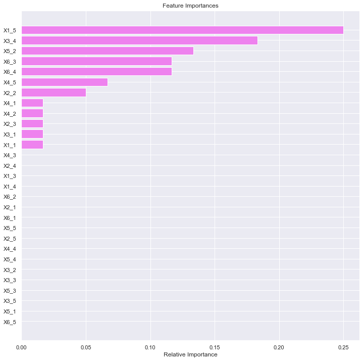

```python
feature_names = X_train.columns
importances = abc_tuned.feature_importances_
indices = np.argsort(importances)

plt.figure(figsize=(12, 12))
plt.title("Feature Importances")
plt.barh(range(len(indices)), importances[indices], color="violet", align="center")
plt.yticks(range(len(indices)), [feature_names[i] for i in indices])
plt.xlabel("Relative Importance")
plt.show()
```